## Project Proposal

#### By Brian Weinfeld

##### March 29, 2018

- Data Collection

```r
games.data <- GET('https://api.mysportsfeeds.com/v1.2/pull/nhl/2015-2016-regular/full_game_schedule.json', authenticate('njpsy', 'asdfasdf'),
            add_headers('Content-Type'='application/json', 'Accept-Encoding'='gzip')) %>%
  content(as='text', encoding='UTF-8') %>%
  fromJSON(flatten=TRUE) %>%
  extract2(1) %>%
  extract2(2) %>%
  as.tibble()

game.dates <- games.data %>%
  select(6) %>%
  mutate(date=str_replace(date, '(\\d+)-(\\d+)-(\\d+)', '\\1\\2\\3')) %>%
  unique()

API.Query <- function(date){
  Sys.sleep(1)
  GET('https://api.mysportsfeeds.com/v1.2/pull/nhl/2015-2016-regular/scoreboard.json', authenticate('njpsy', 'asdfasdf'),
      add_headers('Content-Type'='application/json', 'Accept-Encoding'='gzip'),
      query=list('fordate'=date)) %>%
    content(as='text', encoding='UTF-8') %>%
    fromJSON(flatten=TRUE) %>%
    extract2(1) %>%
    extract2(2) %>%
    as.tibble()
}

box.data <- game.dates$date %>%
  map_df(~API.Query(.)) %>%
  select(8, 24) %>%
  unnest() %>%
  mutate(goals = awayScore %>% as.numeric() + homeScore %>% as.numeric()) %>%
  select(-c(3:6)) %>%
  setNames(c('game.ID'='id', '@number'='period', 'goals'='goals')) %>%
  filter(period %in% 1:3) %>%
  as.tibble()
```

- Research question

In the NHL (National Hockey League), is there a relationship between the period of the game and number of goals scored by either team?

- What are the cases, and how many are there?

Each case represents the number goals scored per period in each game of the 2015-2016 regular hockey season. There are 1230 games, which is the entire population. My “super population” will be all post lockout NHL games (2013-2014 season forward).

- Describe the method of data collection.

Raw data is collected by mysportsfeed.com which maintains an API on all major sports created and supported by fans. I will query the API and collected the required data.

- What type of study is this (observational/experiment)?

This is an observational study.

- Data Source: If you collected the data, state self-collected. If not, provide a citation/link.

The total raw data is collected by mysportsfeed.com, however I will be querying, cleaning and storing the relevant data.

- Response: What is the response variable, and what type is it (numerical/categorical)?

The response variable is the number of goals scored in the period and is numerical.

- Explanatory: What is the explanatory variable(s), and what type is it (numerical/categorival)?

The explanatory variable is the period of the game and is categorical (1st, 2nd or 3rd)

- Relevant summary statistics

```r
box.data %>%
  filter(period == '1') %>%
  select(goals) %>%
  describe()
```

```
##       vars    n mean   sd median trimmed  mad min max range skew kurtosis
## goals    1 1230 1.45 1.19      1    1.34 1.48   0   7     7 0.76     0.43
##         se
## goals 0.03
```

```r
box.data %>%
  filter(period == '2') %>%
  select(goals) %>%
  describe()
```

```
##       vars    n mean   sd median trimmed  mad min max range skew kurtosis
## goals    1 1230 1.83 1.29      2    1.75 1.48   0   7     7 0.55     0.11
##         se
## goals 0.04
```

```r
box.data %>%
  filter(period == '3') %>%
  select(goals) %>%
  describe()
```

```
##       vars    n mean   sd median trimmed  mad min max range skew kurtosis
## goals    1 1230 1.91 1.25      2    1.85 1.48   0   6     6 0.46    -0.03
##         se
## goals 0.04
```

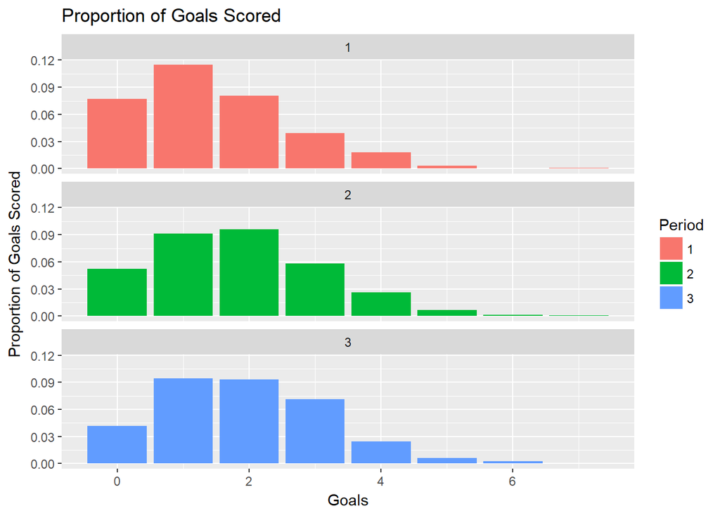

```r
ggplot(box.data) +
  geom_bar(aes(x=goals, y=(..count../sum(..count..)), fill=period))  +
  facet_wrap(~period, nrow=3, ncol=1) +
  labs(x='Goals',
       y='Proportion of Goals Scored',
       fill='Period',
       title='Proportion of Goals Scored')
```